# COMP41680 Assignment 1

#### Student Name: Aasim Shah

#### Student ID: 24203773

#### Data Source: http://mlg.ucd.ie/modules/python/assignment1/cars/index.html

## Introduction

This notebook focuses on **Task 2: Data Preparation and Analysis** of the COMP41680 Assignment 1. It loads the car sales dataset collected in Task 1 from a CSV file into an Analytics Base Table (ABT), applies necessary preprocessing steps to clean and transform the data, and performs an exploratory analysis using visualisations. The notebook concludes with a discussion of challenges faced, key insights gained, and suggestions for further work, as outlined in **Task 3: Discussion**.

## Task 2: Data Preparation and Analysis

## Data Preprocessing:

```python
"""
Import necessary libraries for data analysis and visualization.

Libraries imported:
    pandas (pd): For data manipulation and analysis using DataFrames.
    matplotlib.pyplot (plt): For creating static, interactive, and animated visualizations.
    seaborn (sns): For creating statistically informative and visually appealing plots.
"""
import pandas as pd
import matplotlib.pyplot as plt
import seaborn as sns
```

```python
"""
Set the default style for Seaborn plots.

This function configures the aesthetic style of plots generated by Seaborn.
The 'whitegrid' style is applied, which adds a light gray grid to the background
of the plots for better readability.

Attributes:
    style (str): The name of the style to be applied. Default is 'whitegrid'.
"""
sns.set(style="whitegrid")
```

```python
"""
Load data from a CSV file into a pandas DataFrame.

This function reads data from a specified CSV file and creates a pandas DataFrame,
which is a tabular data structure suitable for data analysis.

Attributes:
    'data.csv' (str): The path to the CSV file to be loaded.

Returns:
    DataFrame: A pandas DataFrame containing the data from the CSV file.
"""
df = pd.read_csv('car_sales_data.csv')
```

```python
"""
Display the first five rows of the DataFrame.

This method is used to quickly inspect the top five rows of the DataFrame,
allowing a preview of the dataset structure, including column names and some sample data.

Attributes:
    df (DataFrame): The pandas DataFrame whose first five rows are to be displayed.

Returns:
    DataFrame: The first five rows of the DataFrame. If the DataFrame contains fewer
    than five rows, all rows will be displayed.
"""
df.head()
```

|  | Make | Make/Model | Date of Sale | Sale Price | Year | Mileage | Classification | Transmission | Fuel Type | Description | Sale Location |
| --- | --- | --- | --- | --- | --- | --- | --- | --- | --- | --- | --- |
| 0 | Audi | Audi A1 (TFSI) | 06/01/2024 | €4,800.00 | 2012 | 130,377 | Hatchback | Manual | Petrol | Grey Audi A11.4 TFSI Sport Euro 5 (s/s) 3dr2 p... | Waterford |
| 1 | Audi | Audi Q7 (S line Plus) | 07/01/2024 | €14,450.00 | 2012 | 91,483 | SUV | Automatic | Diesel | Blue Audi Q73.0 TDI S line Plus Tiptronic quat... | Clare |
| 2 | Audi | Audi RS3 (TFSI) | 09/01/2024 | €70,256.00 | 2022 | 3,869 | Saloon | Automatic | Petrol | Black Audi RS3 SALOON2.5 RS 3 TFSI QUATTRO VOR... | Mayo |
| 3 | Audi | Audi A3 (S line) | 09/01/2024 | €10,308.00 | 2013 | 83,389 | Hatchback | Manual | Diesel | Black Audi A32.0 TDI S line Hatchback 3dr Dies... | Limerick |
| 4 | Audi | Audi A6 Saloon (ultra) | 2024-01-09 | €21,833.00 | 2018 | 42,918 | Saloon | Automatic | Diesel | Red Audi A6 Saloon2.0 TDI Ultra Black Edition ... | Dublin |

```python
"""
Prints a concise summary of the DataFrame.

Displays:
    - Index type and column data types.
    - Non-null values count in each column.
    - Memory usage of the DataFrame.

Returns:
    None (this method prints the information to the console).
"""
df.info()
```

```
<class 'pandas.core.frame.DataFrame'>
RangeIndex: 1700 entries, 0 to 1699
Data columns (total 11 columns):
 #   Column          Non-Null Count  Dtype
---  ------          --------------  -----
 0   Make            1700 non-null   object
 1   Make/Model      1700 non-null   object
 2   Date of Sale    1700 non-null   object
 3   Sale Price      1700 non-null   object
 4   Year            1700 non-null   int64
 5   Mileage         1700 non-null   object
 6   Classification  1700 non-null   object
 7   Transmission    1700 non-null   object
 8   Fuel Type       1700 non-null   object
 9   Description     1700 non-null   object
 10  Sale Location   1700 non-null   object
dtypes: int64(1), object(10)
memory usage: 146.2+ KB
```

```python
"""
Returns the number of unique values in each column of the DataFrame.

Parameters:
    dropna (bool, optional): If True (default), NaN values are excluded from the count.

Returns:
    pandas.Series: A Series with the number of unique values for each column.
"""
df.nunique()
```

```
Make                 4
Make/Model         560
Date of Sale       553
Sale Price        1663
Year                15
Mileage           1696
Classification       7
Transmission         3
Fuel Type            7
Description       1689
Sale Location       26
dtype: int64
```

```python
"""
Returns the total number of missing (null) values in each column of the DataFrame.

Returns:
    pandas.Series: A Series with the count of null values for each column.

Note:
    - The method first identifies null values using `isnull()`.
    - Then, it sums the null values for each column using `sum()`.
"""
df.isnull().sum()
```

```
Make              0
Make/Model        0
Date of Sale      0
Sale Price        0
Year              0
Mileage           0
Classification    0
Transmission      0
Fuel Type         0
Description       0
Sale Location     0
dtype: int64
```

```python
df['Sale Price'].head()
```

```
0     €4,800.00
1    €14,450.00
2    €70,256.00
3    €10,308.00
4    €21,833.00
Name: Sale Price, dtype: object
```

```python
"""
Cleans and converts the 'Sale Price' column in the DataFrame to float values.

This code processes the 'Sale Price' column by removing the euro symbol ('€'), commas, and extra whitespace from
string values (e.g., '€ 7,166'), then converts the result to floating-point numbers. The first few entries are
returned to verify the transformation.

Parameters:
    df (pandas.DataFrame): The input DataFrame containing a 'Sale Price' column with string values (e.g., '€12,345').

Returns:
    pandas.Series: The first 5 entries of the transformed 'Sale Price' column for verification.

Notes:
    - `str.replace('€', '')` removes the currency symbol to isolate the numeric value.
    - `str.replace(',', '')` removes commas for proper numeric conversion.
    - `str.strip()` eliminates leading/trailing whitespace that could interfere with parsing.
    - `astype(float)` converts the cleaned strings to floating-point numbers, suitable for numerical analysis.
"""
df['Sale Price'] = df['Sale Price'].str.replace('€', '').str.replace(',', '').str.strip().astype(float)
df['Sale Price'].head()
```

```
0     4800.0
1    14450.0
2    70256.0
3    10308.0
4    21833.0
Name: Sale Price, dtype: float64
```

```python
"""
Cleans and converts the 'Mileage' column in the DataFrame to integer values.

This code processes the 'Mileage' column by removing commas, extracting the numeric portion from strings that may
include units (e.g., '130,377 miles'), and converting the result to integers. The first few entries are returned
to verify the transformation.

Parameters:
    df (pandas.DataFrame): The input DataFrame containing a 'Mileage' column with string values (e.g., '20,457 miles').

Returns:
    pandas.Series: The first 5 entries of the transformed 'Mileage' column for verification.

Notes:
    - `str.replace(',', '')` removes commas from mileage strings for cleaner numeric extraction.
    - `str.extract(r'(\d+)')` captures the first sequence of digits, discarding any trailing text like 'miles'.
    - `astype(int)` converts the extracted strings to integers, assuming all entries have at least one numeric value.
"""
df['Mileage'] = df['Mileage'].str.replace(',', '').str.extract(r'(\d+)').astype(int)
df['Mileage'].head()
```

```
0    130377
1     91483
2      3869
3     83389
4     42918
Name: Mileage, dtype: int32
```

```python
"""
Converts the 'Date of Sale' column in the DataFrame to a standardized DD/MM/YYYY string format.

This code processes the 'Date of Sale' column by parsing mixed date formats with a preference for day-first
interpretation (common in European datasets), handling invalid entries gracefully, and reformatting the result
as a string in 'DD/MM/YYYY' format for consistency. The transformation is verified by printing the first few entries.

Parameters:
    df (pandas.DataFrame): The input DataFrame containing a 'Date of Sale' column with date strings in various formats.

Returns:
    None: Modifies the 'Date of Sale' column in-place and prints the first 5 entries for verification.

Notes:
    - Uses `format='mixed'` and `dayfirst=True` to handle inconsistent date formats (e.g., '06/01/2024' or '2024-01-09').
    - `errors='coerce'` ensures invalid dates become NaT (Not a Time) rather than raising exceptions.
    - The final `.dt.strftime('%d/%m/%Y')` converts datetime objects back to strings in the desired format.
"""
df['Date of Sale'] = pd.to_datetime(df['Date of Sale'], format='mixed', dayfirst=True, errors='coerce').dt.strftime('%d/%m/%Y')
df['Date of Sale'].head()
```

```
0    06/01/2024
1    07/01/2024
2    09/01/2024
3    09/01/2024
4    09/01/2024
Name: Date of Sale, dtype: object
```

```python
"""
Standardizes the 'Classification' column in the DataFrame by removing periods.

This code processes the 'Classification' column by removing all periods from string values to ensure consistency
(e.g., converting 'S.U.V.' to 'SUV'). The unique values are returned to verify that similar categories are unified.

Parameters:
    df (pandas.DataFrame): The input DataFrame containing a 'Classification' column with string values (e.g., 'SUV', 'S.U.V.').

Returns:
    numpy.ndarray: An array of unique values in the 'Classification' column after standardization.

Notes:
    - `str.replace('.', '')` removes periods to align similar classifications, such as 'SUV' and 'S.U.V.', into a single category.
    - This step addresses data inconsistencies observed in the dataset, improving grouping and analysis accuracy.
"""
df['Classification'] = df['Classification'].str.replace('.', '')
df['Classification'].unique()
```

```
array(['Hatchback', 'SUV', 'Saloon', 'Convertible', 'Estate', 'Coupe'],
      dtype=object)
```

```python
"""
Standardizes the 'Transmission' column in the DataFrame by replacing 'Auto' with 'Automatic'.

This code processes the 'Transmission' column by replacing instances of the value 'Auto' with 'Automatic' to ensure consistency
in transmission type representation. The unique values in the 'Transmission' column are returned to verify the changes.

Parameters:
    df (pandas.DataFrame): The input DataFrame containing a 'Transmission' column with string values (e.g., 'Auto', 'Manual').

Returns:
    numpy.ndarray: An array of unique values in the 'Transmission' column after the replacement.

Notes:
    - `str.replace('Auto', 'Automatic')` replaces shorthand notation 'Auto' with the full term 'Automatic'.
    - This step ensures that transmission types are consistently represented, improving analysis accuracy.
"""
df['Transmission'] = df['Transmission'].replace('Auto','Automatic')
df['Transmission'].unique()
```

```
array(['Manual', 'Automatic'], dtype=object)
```

```python
"""
Generates summary statistics for numerical columns in the DataFrame.

This code computes descriptive statistics (e.g., count, mean, standard deviation, min, max, quartiles) for all
numerical columns in the DataFrame, providing a quick overview of their distributions and central tendencies.

Parameters:
    df (pandas.DataFrame): The input DataFrame containing numerical columns to summarize (e.g., 'Sale Price', 'Mileage').

Returns:
    pandas.DataFrame: A DataFrame with summary statistics for each numerical column.

Notes:
    - Includes metrics such as mean, standard deviation, and percentiles (25%, 50%, 75%).
    - Non-numerical columns (e.g., strings) are automatically excluded from the output.
"""
df.describe()
```

|  | Sale Price | Year | Mileage |
| --- | --- | --- | --- |
| count | 1700.000000 | 1700.000000 | 1700.000000 |
| mean | 21732.065882 | 2016.150000 | 53320.732941 |
| std | 16455.951135 | 3.458043 | 35767.395837 |
| min | 1151.000000 | 2008.000000 | 26.000000 |
| 25% | 11042.500000 | 2014.000000 | 23394.000000 |
| 50% | 17704.000000 | 2017.000000 | 47644.500000 |
| 75% | 27176.500000 | 2019.000000 | 77502.000000 |
| max | 215403.000000 | 2022.000000 | 195191.000000 |

## Data Visualisation:

### Histogram: Distribution of Sale Prices

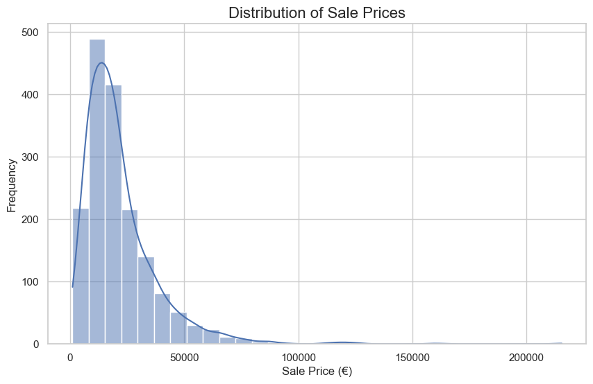

```python
"""
Creates and displays a histogram for the 'Sale Price' column of the DataFrame with a kernel density estimate (KDE) overlay.

Steps:
    1. Initializes a figure with specified dimensions (10x6 inches).
    2. Plots a histogram using Seaborn's `histplot()` for the 'Sale Price' column.
        - `bins=30`: Divides the data into 30 bins.
        - `kde=True`: Adds a kernel density estimate curve to the histogram.
    3. Sets the title and labels for the x and y axes.
    4. Displays the plot using `plt.show()`.

Parameters:
    df (pandas.DataFrame): DataFrame containing the 'Sale Price' column to plot.

Returns:
    None
"""
plt.figure(figsize=(10, 6))
sns.histplot(df['Sale Price'], bins=30, kde=True)
plt.title('Distribution of Sale Prices', fontsize=16)
plt.xlabel('Sale Price (€)')
plt.ylabel('Frequency')
plt.show()
```

##### Description:

The histogram displays the distribution of sale prices for cars in euros, with a kernel density estimate (KDE) curve overlaid to show the smoothed distribution shape.

##### Revelation:

Most cars have relatively low sale prices, with a significant concentration below €50,000, as indicated by the peak in the histogram and KDE curve. However, there is a long tail extending towards higher prices, reaching up to €200,000, suggesting that while the majority of cars are affordable, a small number of high-value cars (likely luxury models) exist. The right-skewed distribution highlights that the car market in this dataset is dominated by lower to mid-range priced vehicles, with a few outliers commanding significantly higher prices.

### Scatter Plot: Mileage vs. Sale Price

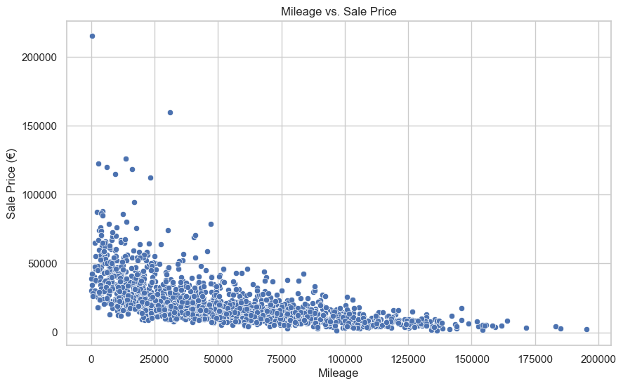

```python
"""
Creates and displays a scatter plot for 'Mileage' vs. 'Sale Price' from the DataFrame.

Steps:
    1. Initializes a figure with specified dimensions (10x6 inches).
    2. Plots a scatter plot using Seaborn's `scatterplot()` with 'Mileage' on the x-axis and 'Sale Price' on the y-axis.
    3. Sets the title and labels for the x and y axes.
    4. Displays the plot using `plt.show()`.

Parameters:
    df (pandas.DataFrame): DataFrame containing the 'Mileage' and 'Sale Price' columns to plot.

Returns:
    None
"""
plt.figure(figsize=(10, 6))
sns.scatterplot(x='Mileage', y='Sale Price', data=df)
plt.title('Mileage vs. Sale Price')
plt.xlabel('Mileage')
plt.ylabel('Sale Price (€)')
plt.show()
```

##### Description:

The scatter plot displays the relationship between mileage and sale price, with mileage on the x-axis and sale price in euros on the y-axis, where each point represents an individual car sale.

##### Revelation:

There is a clear negative trend between mileage and sale price, with most cars having high mileage (above 100,000) clustering at lower sale prices (below €50,000), while cars with lower mileage (below 50,000) tend to have higher sale prices (up to €200,000). This indicates that higher mileage significantly reduces a car’s value, likely due to increased wear and tear. The dense clustering at lower mileage and mid-range prices suggests that many cars in this dataset are moderately used and sold at affordable prices, with fewer low-mileage, high-value outliers.

### Bar Plot: Average Sale Price by Make

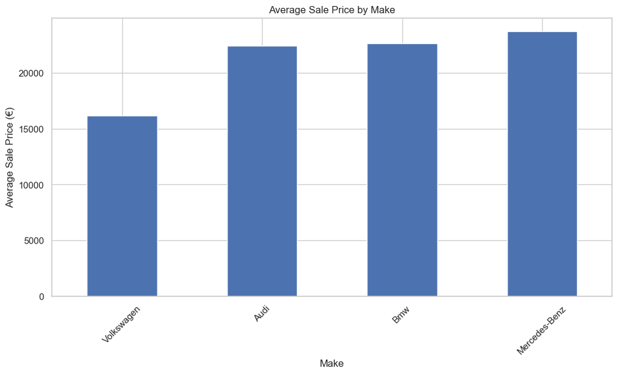

```python
"""
Creates and displays a bar plot showing the average sale price by car make.

Steps:
    1. Initializes a figure with specified dimensions (12x6 inches).
    2. Groups the DataFrame by the 'Make' column and calculates the mean of the 'Sale Price' for each group.
    3. Sorts the mean sale prices in ascending order and plots a bar chart using `plot(kind='bar')`.
    4. Sets the title and labels for the x and y axes.
    5. Rotates the x-axis labels by 45 degrees for better readability.
    6. Displays the plot using `plt.show()`.

Parameters:
    df (pandas.DataFrame): DataFrame containing the 'Make' and 'Sale Price' columns to plot.

Returns:
    None
"""
plt.figure(figsize=(12, 6))
df.groupby('Make')['Sale Price'].mean().sort_values().plot(kind='bar')
plt.title('Average Sale Price by Make')
plt.xlabel('Make')
plt.ylabel('Average Sale Price (€)')
plt.xticks(rotation=45)
plt.show()
```

##### Description:

The bar plot displays the average sale price for each car make (e.g., Volkswagen, Audi, BMW, Mercedes-Benz) in euros.

##### Revelation:

Mercedes-Benz has the highest average sale price, exceeding €20,000, followed closely by BMW and Audi, while Volkswagen has the lowest at around €15,000. This suggests that Mercedes-Benz, BMW, and Audi are positioned as premium brands in this dataset, commanding higher prices, possibly due to luxury models or brand perception, whereas Volkswagen caters to a more budget-conscious market.

### Line Plot: Number of Sales Over Time

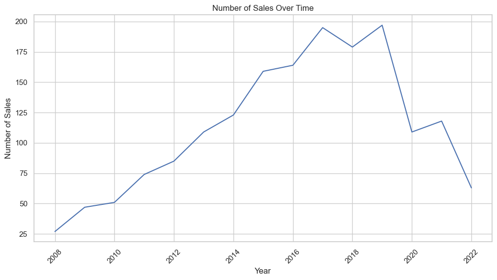

```python
"""
Creates and displays a line plot showing the number of sales over time.

Steps:
    1. Groups the DataFrame by the 'Year' column and calculates the number of sales per year using `size()`.
    2. Initializes a figure with specified dimensions (12x6 inches).
    3. Plots the number of sales over time as a line plot using `plot()`.
    4. Sets the title and labels for the x and y axes.
    5. Rotates the x-axis labels by 45 degrees for better readability.
    6. Displays the plot using `plt.show()`.

Parameters:
    df (pandas.DataFrame): DataFrame containing the 'Year' column to group and plot the number of sales.

Returns:
    None
"""
sales_over_time = df.groupby('Year').size()

plt.figure(figsize=(12, 6))
sales_over_time.plot()
plt.title('Number of Sales Over Time')
plt.xlabel('Year')
plt.ylabel('Number of Sales')
plt.xticks(rotation=45)
plt.show()
```

##### Description:

The line plot shows the number of car sales over time, with the x-axis representing years (2008–2022) and the y-axis showing the number of sales.

##### Revelation:

Sales volume increased steadily from 2008 to around 2018, peaking at almost 200 sales, but then declined sharply towards 2022, dropping below 75 sales. This trend suggests a potential market shift, possibly due to economic factors, changing consumer preferences (e.g., towards electric vehicles), or external events like supply chain disruptions affecting car availability.

### Bar Plot: Average Sale Price by Fuel Type

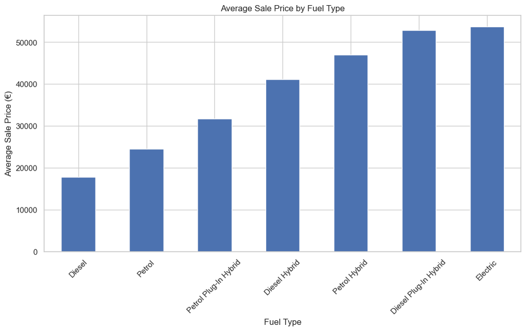

```python
"""
Creates and displays a bar plot showing the average sale price by fuel type.

Steps:
    1. Initializes a figure with specified dimensions (12x6 inches).
    2. Groups the DataFrame by the 'Fuel Type' column and calculates the mean of the 'Sale Price' for each group.
    3. Sorts the mean sale prices in ascending order and plots a bar chart using `plot(kind='bar')`.
    4. Sets the title and labels for the x and y axes.
    5. Rotates the x-axis labels by 45 degrees for better readability.
    6. Displays the plot using `plt.show()`.

Parameters:
    df (pandas.DataFrame): DataFrame containing the 'Fuel Type' and 'Sale Price' columns to plot.

Returns:
    None
"""
plt.figure(figsize=(12, 6))
df.groupby('Fuel Type')['Sale Price'].mean().sort_values().plot(kind='bar')
plt.title('Average Sale Price by Fuel Type')
plt.xlabel('Fuel Type')
plt.ylabel('Average Sale Price (€)')
plt.xticks(rotation=45)
plt.show()
```

##### Description:

The bar plot displays the average sale price for cars by fuel type (e.g., Diesel, Petrol, Hybrid, Electric).

##### Revelation:

Electric cars have the highest average sale price, around €50,000, followed by Diesel Plug-in Hybrid and Petrol Hybrid, while Diesel cars have the lowest at around €15,000. This indicates that electric vehicles are significantly more expensive, likely due to newer technology and market demand, whereas diesel cars, possibly older or less desirable, command lower prices.

### Boxplot: Sale Price Distribution by Transmission Type

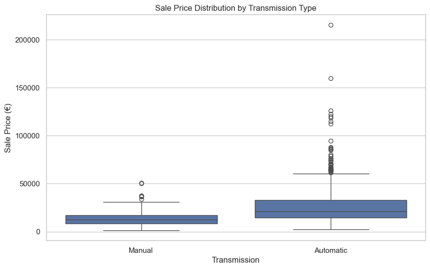

```python
"""
Creates and displays a box plot showing the distribution of sale prices by transmission type.

Steps:
    1. Initializes a figure with specified dimensions (10x6 inches).
    2. Plots a box plot using Seaborn's `boxplot()` with 'Transmission' on the x-axis and 'Sale Price' on the y-axis.
    3. Sets the title and labels for the x and y axes.
    4. Displays the plot using `plt.show()`.

Parameters:
    df (pandas.DataFrame): DataFrame containing the 'Transmission' and 'Sale Price' columns to plot.

Returns:
    None
"""
plt.figure(figsize=(10, 6))
sns.boxplot(x='Transmission', y='Sale Price', data=df)
plt.title('Sale Price Distribution by Transmission Type')
plt.xlabel('Transmission')
plt.ylabel('Sale Price (€)')
plt.show()
```

##### Description:

The boxplot displays the distribution of sale prices in euros across different transmission types (Manual and Automatic) for cars in the dataset.

### Violin Plot: Sale Price Distribution by Fuel Type

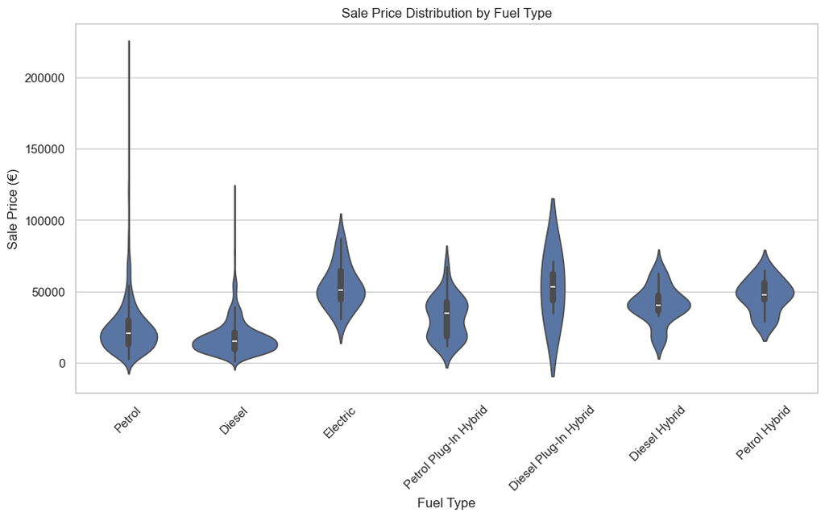

```python
"""
Creates and displays a violin plot showing the distribution of sale prices by fuel type.

Steps:
    1. Initializes a figure with specified dimensions (12x6 inches).
    2. Plots a violin plot using Seaborn's `violinplot()` with 'Fuel Type' on the x-axis and 'Sale Price' on the y-axis.
    3. Sets the title and labels for the x and y axes.
    4. Rotates the x-axis labels by 45 degrees for better readability.
    5. Displays the plot using `plt.show()`.

Parameters:
    df (pandas.DataFrame): DataFrame containing the 'Fuel Type' and 'Sale Price' columns to plot.

Returns:
    None
"""
plt.figure(figsize=(12, 6))
sns.violinplot(x='Fuel Type', y='Sale Price', data=df)
plt.title('Sale Price Distribution by Fuel Type')
plt.xlabel('Fuel Type')
plt.ylabel('Sale Price (€)')
plt.xticks(rotation=45)
# plt.yticks(range(12)
plt.show()
```

##### Description:

The violin plot displays the distribution of sale prices across fuel types, showing both the density and range of prices.

### Heatmap: Correlation Heatmap of Numerical Variables

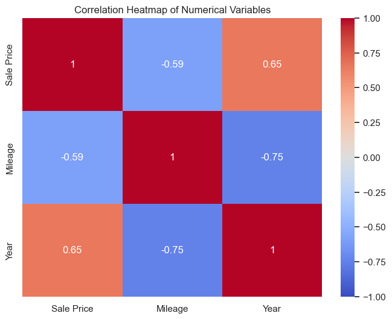

```python
"""
Creates and displays a heatmap showing the correlation between numerical variables.

Steps:
    1. Selects the numerical columns ('Sale Price', 'Mileage', 'Year') from the DataFrame.
    2. Calculates the correlation matrix for the selected numerical columns using `.corr()`.
    3. Initializes a figure with specified dimensions (8x6 inches).
    4. Plots a heatmap using Seaborn's `heatmap()` to visualize the correlation matrix.
        - `annot=True`: Displays the correlation coefficients on the heatmap.
        - `cmap='coolwarm'`: Applies the 'coolwarm' colormap to the heatmap.
        - `vmin=-1, vmax=1`: Sets the color scale limits for the heatmap.
    5. Sets the title for the heatmap.
    6. Displays the heatmap using `plt.show()`.

Parameters:
    df (pandas.DataFrame): DataFrame containing the numerical columns for correlation calculation.

Returns:
    None
"""
numerical_cols = ['Sale Price', 'Mileage', 'Year']
correlation_matrix = df[numerical_cols].corr()

plt.figure(figsize=(8, 6))
sns.heatmap(correlation_matrix, annot=True, cmap='coolwarm', vmin=-1, vmax=1)
plt.title('Correlation Heatmap of Numerical Variables')
plt.show()
```

##### Description:

The heatmap shows the correlation coefficients between numerical variables (Sale Price, Mileage, Year), with values ranging from -1 to 1.

##### Revelation:

There’s a strong negative correlation (-0.59) between Mileage and Sale Price, confirming that higher mileage significantly reduces a car’s value. Sale Price and Year have a positive correlation (0.65), indicating newer cars tend to be more expensive. Mileage and Year are negatively correlated (-0.75), suggesting newer cars have lower mileage, which aligns with expectations. These relationships highlight key factors influencing car prices in this dataset.

### Bar Plot: Top 10 Car Models by Number of Sales

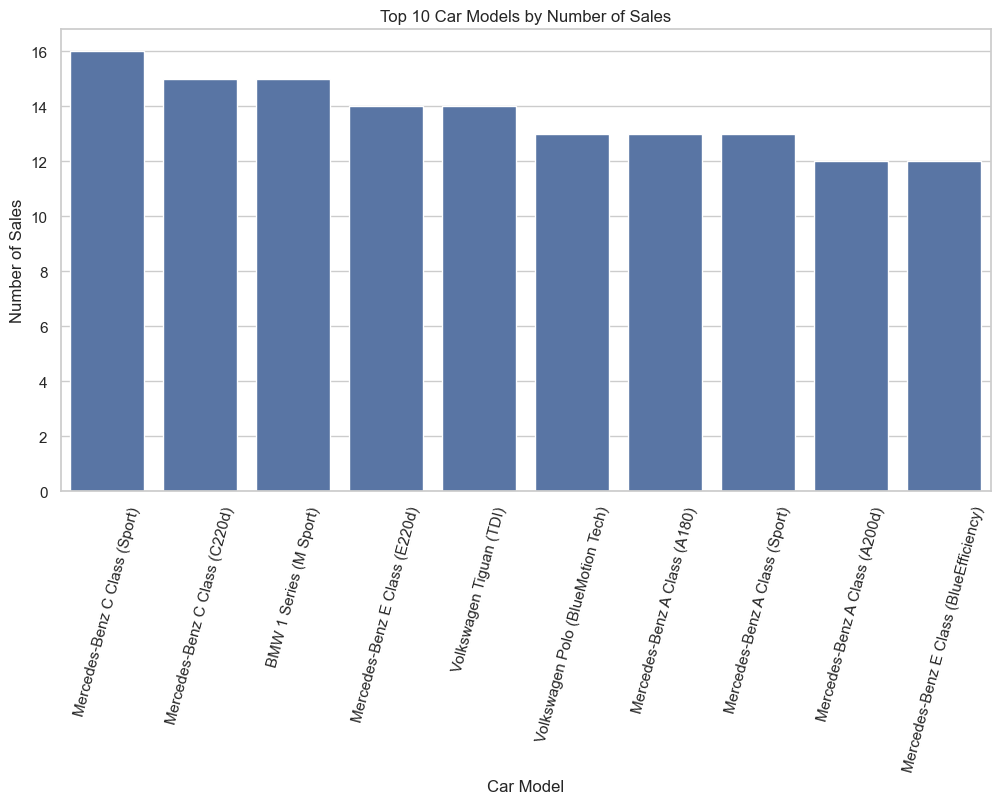

```python
"""
Creates and displays a bar plot showing the top 10 car models by the number of sales.

Steps:
    1. Calculates the number of sales for each car model using `value_counts()` and selects the top 10.
    2. Initializes a figure with specified dimensions (12x6 inches).
    3. Plots a bar chart using Seaborn's `barplot()` with car models on the x-axis and the number of sales on the y-axis.
    4. Sets the title and labels for the x and y axes.
    5. Rotates the x-axis labels by 75 degrees for better readability.
    6. Displays the plot using `plt.show()`.

Parameters:
    df (pandas.DataFrame): DataFrame containing the 'Make/Model' column to calculate the number of sales.

Returns:
    None
"""
plt.figure(figsize=(12, 6))
top_models = df['Make/Model'].value_counts().head(10)
sns.barplot(x=top_models.index, y=top_models.values)
plt.title('Top 10 Car Models by Number of Sales')
plt.xlabel('Car Model')
plt.ylabel('Number of Sales')
plt.xticks(rotation=75)
plt.show()
```

##### Revelation:

The Mercedes-Benz C Class (Sports) leads with around 16 sales, followed by models like the The Mercedes-Benz C Class (C220d) and BMW 1 Series (M Sport), each with 15 sales. The distribution is relatively even among the top models, with no single model dominating significantly. This suggests a balanced market preference for these popular models, likely reflecting their reliability, brand appeal, or availability.

### Stacked Bar Plot: Car Classification by Fuel Type

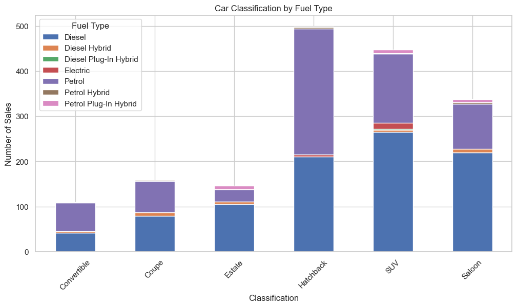

```python
"""
Creates and displays a stacked bar plot showing car classification by fuel type.

Steps:
    1. Groups the DataFrame by 'Classification' and 'Fuel Type' and calculates the number of sales for each combination using `size()`.
    2. Uses `unstack()` to reshape the data into a table format and fills missing values with 0 using `fillna(0)`.
    3. Initializes a figure with specified dimensions (12x6 inches).
    4. Plots a stacked bar chart using `plot(kind='bar', stacked=True)` to show the number of sales by classification and fuel type.
    5. Sets the title and labels for the x and y axes.
    6. Rotates the x-axis labels by 45 degrees for better readability.
    7. Adds a legend with the title 'Fuel Type' to indicate different fuel types.
    8. Displays the plot using `plt.show()`.

Parameters:
    df (pandas.DataFrame): DataFrame containing the 'Classification' and 'Fuel Type' columns to plot the number of sales.

Returns:
    None
"""
plt.figure(figsize=(12, 6))
fuel_by_class = df.groupby(['Classification', 'Fuel Type']).size().unstack().fillna(0)
fuel_by_class.plot(kind='bar', stacked=True, figsize=(12, 6))
plt.title('Car Classification by Fuel Type')
plt.xlabel('Classification')
plt.ylabel('Number of Sales')
plt.xticks(rotation=45)
plt.legend(title='Fuel Type')
plt.show()
```

##### Description:

The stacked bar plot displays the number of sales by car classification (e.g., SUV, Hatchback) with stacks representing different fuel types (Diesel, Petrol, Electric, etc.).

### Pair Plot : Pair Plot of Numerical Variables by Fuel Type

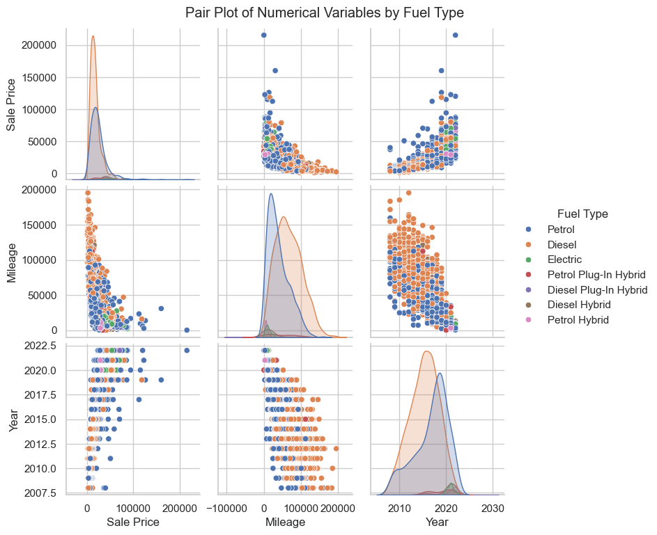

```python
"""
Creates and displays a pair plot showing relationships between numerical variables, colored by fuel type.

Steps:
    1. Initializes a figure with specified dimensions (10x8 inches).
    2. Plots a pair plot using Seaborn's `pairplot()` for the numerical variables ['Sale Price', 'Mileage', 'Year'].
        - `hue='Fuel Type'`: Colors the data points based on the 'Fuel Type' column.
    3. Sets the title for the pair plot using `plt.suptitle()` with a vertical adjustment (`y=1.02`) to prevent overlap with the plot.
    4. Displays the plot using `plt.show()`.

Parameters:
    df (pandas.DataFrame): DataFrame containing the 'Sale Price', 'Mileage', 'Year', and 'Fuel Type' columns to plot.

Returns:
    None
"""
plt.figure(figsize=(10, 8))
sns.pairplot(df, vars=['Sale Price', 'Mileage', 'Year'], hue='Fuel Type')
plt.suptitle('Pair Plot of Numerical Variables by Fuel Type', y=1.02)
plt.show()
```

##### Description:

The pair plot shows pairwise relationships between Sale Price, Mileage, and Year, with points colored by Fuel Type (Petrol, Diesel, Electric, etc.).

##### Revelation:

Electric cars cluster at high Sale Prices (€50,000+) and low Mileage, indicating they are newer and more expensive. Diesel and Petrol cars dominate lower price ranges (€10,000–€20,000) with higher mileage, reflecting older, more used vehicles. The Year vs. Sale Price scatter shows a clear upward trend for all fuel types, but Electric cars are concentrated in recent years (2018+), highlighting their recent market entry. The histograms reveal right-skewed distributions for Sale Price and Mileage, with Year peaking around 2015–2020.

### Pie Chart: Proportion of Sales by Make

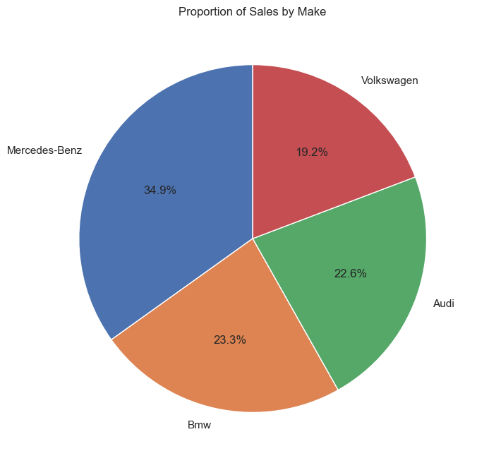

```python
"""
Creates and displays a pie chart showing the proportion of sales by car make.

Steps:
    1. Initializes a figure with specified dimensions (8x8 inches).
    2. Calculates the number of sales for each car make using `value_counts()`.
    3. Plots a pie chart using `plt.pie()` to visualize the proportion of sales for each car make.
        - `labels=make_counts.index`: Uses car make names as labels.
        - `autopct='%1.1f%%'`: Displays the percentage of each make in the chart.
        - `startangle=90`: Rotates the pie chart for better alignment.
    4. Sets the title of the pie chart.
    5. Displays the plot using `plt.show()`.

Parameters:
    df (pandas.DataFrame): DataFrame containing the 'Make' column to calculate the sales proportions.

Returns:
    None
"""
plt.figure(figsize=(8, 8))
make_counts = df['Make'].value_counts()
plt.pie(make_counts, labels=make_counts.index, autopct='%1.1f%%', startangle=90)
plt.title('Proportion of Sales by Make')
plt.show()
```

##### Description:

The pie chart displays the proportion of total sales by car make (Mercedes-Benz, Audi, BMW, Volkswagen).

##### Revelation:

Mercedes-Benz leads with 34.9% of sales, followed by BMW (23.3%), Audi (22.6%), and Volkswagen (19.2%). The relatively even split among makes indicates a competitive market, with Mercedes-Benz having a slight edge, possibly due to a broader range of models or stronger brand presence in the scraped dataset.

### Bar Plot: Average Mileage by Classification

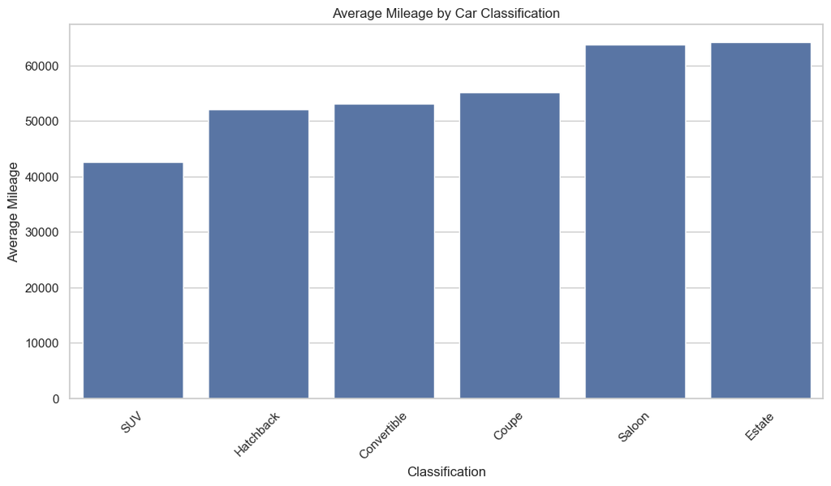

```python
"""
Creates and displays a bar plot showing the average mileage by car classification.

Steps:
    1. Groups the DataFrame by 'Classification' and calculates the mean mileage for each classification using `.mean()`.
    2. Sorts the average mileage values in ascending order using `.sort_values()`.
    3. Initializes a figure with specified dimensions (12x6 inches).
    4. Plots a bar chart using Seaborn's `barplot()` with 'Classification' on the x-axis and the average mileage on the y-axis.
    5. Sets the title and labels for the x and y axes.
    6. Rotates the x-axis labels by 45 degrees for better readability.
    7. Displays the plot using `plt.show()`.

Parameters:
    df (pandas.DataFrame): DataFrame containing the 'Classification' and 'Mileage' columns to calculate the average mileage.

Returns:
    None
"""
plt.figure(figsize=(12, 6))
avg_mileage_by_class = df.groupby('Classification')['Mileage'].mean().sort_values()
sns.barplot(x=avg_mileage_by_class.index, y=avg_mileage_by_class.values)
plt.title('Average Mileage by Car Classification')
plt.xlabel('Classification')
plt.ylabel('Average Mileage')
plt.xticks(rotation=45)
plt.show()
```

##### Description:

The bar plot shows the average mileage for each car classification (e.g., SUV, Hatchback, Estate).

##### Revelation:

Estates and Saloons have the highest average mileage (around 65,000), followed by Coupes (around 55,000), while SUVs have the lowest (around 40,000). This suggests Estates and Saloons are used for longer trips or by owners who drive more, while SUVs, likely seasonal or secondary vehicles, accumulate less mileage. The variation highlights differing usage patterns across car types.

### Scatter Plot: Sale Price vs. Year with Regression Line

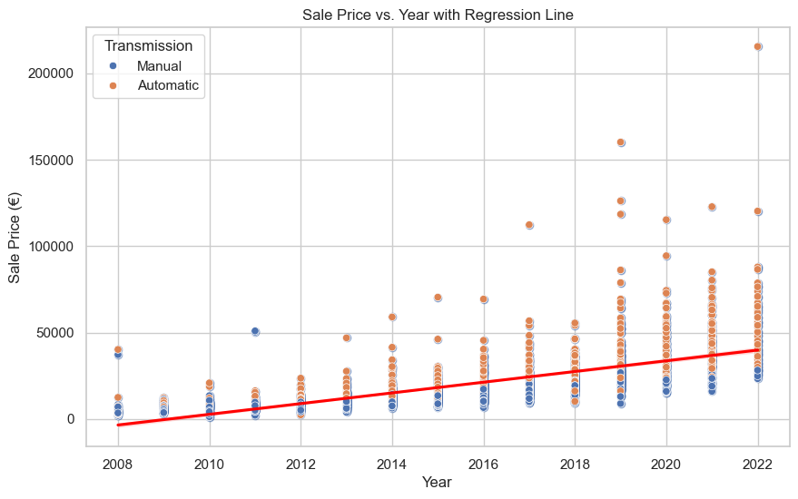

```python
"""
Creates and displays a scatter plot showing the relationship between sale price and year, with a regression line.

Steps:
    1. Initializes a figure with specified dimensions (10x6 inches).
    2. Plots a regression line using Seaborn's `regplot()` with 'Year' on the x-axis and 'Sale Price' on the y-axis.
        - `scatter_kws={'alpha':0.5}`: Sets the transparency of the scatter plot points.
        - `line_kws={'color':'red'}`: Colors the regression line in red.
    3. Overlays a scatter plot using Seaborn's `scatterplot()` to show the data points, with points colored by 'Transmission' type.
    4. Sets the title and labels for the x and y axes.
    5. Displays the plot using `plt.show()`.

Parameters:
    df (pandas.DataFrame): DataFrame containing the 'Year', 'Sale Price', and 'Transmission' columns to plot.

Returns:
    None
"""
plt.figure(figsize=(10, 6))
sns.regplot(x='Year', y='Sale Price', data=df, scatter_kws={'alpha':0.5}, line_kws={'color':'red'})
sns.scatterplot(x='Year', y='Sale Price', hue='Transmission', data=df)
plt.title('Sale Price vs. Year with Regression Line')
plt.xlabel('Year')
plt.ylabel('Sale Price (€)')
plt.show()
```

##### Description:

The scatter plot with a regression line shows the relationship between the year of the car and its sale price in euros, with points coloured by transmission type (Manual in blue, Automatic in orange).

##### Revelation:

The upward-sloping regression line confirms a positive relationship between year and sale price, with newer cars (post-2015) generally having higher prices (up to €200,000) compared to older cars (pre-2010), which are mostly below €50,000. Automatic cars dominate the newer, higher-priced segment (2015–2022), while Manual cars are more common among older, lower-priced cars (pre-2015). This suggests a market shift towards automatic transmissions in recent years, likely reflecting consumer preferences for convenience in newer models, while older manual cars remain in the lower price bracket due to age and depreciation.

## Task 3: Discussion

### a) Challenges Faced When Scraping and Cleaning the Data

##### Web Scraping Challenges (Task 1):

- Navigating Multiple Pages per Make: The website required scraping data across multiple pages for each car make (Audi: 20 pages, BMW: 20 pages, Mercedes-Benz: 30 pages, Volkswagen: 17 pages), totaling 87 pages. This necessitated a two-level scraping approach: first, extracting links to each make from the index page, and then iterating through paginated links (e.g., Audi-page01.html to Audi-page20.html). Constructing the correct URLs programmatically (e.g., by incrementing page numbers in the URL pattern) was challenging, especially since the number of pages varied by make, requiring dynamic logic to determine the last page for each make.
- Extracting Data from Tables: Each page contained a table with car listings, but the table structure required careful parsing. For example, columns like 'Sale Price' included currency symbols ('€') and commas, which needed to be removed later during cleaning. Ensuring all columns (e.g., 'Date of Sale', 'Mileage', 'Fuel Type') were consistently extracted across pages was tricky, especially if some listings had missing data.
- Handling Missing or Inconsistent Data During Scraping: Some listings might have had missing fields, which could lead to misaligned data when populating the DataFrame. Additionally, the 'Classification' and the 'Transmission' columns had inconsistent labels, which weren’t standardised during scraping and carried over into the cleaning phase.

### c) Suggestions for Further Work

The analysis conducted in this notebook offers a solid foundation, but there are several avenues for further exploration and enhancement of the dataset:

##### Alternative Analyses:

- Predictive Modeling: Build a regression model (e.g., linear regression, random forest) to predict sale price based on features like Mileage, Year, Fuel Type, and Make. This could help quantify the relative importance of each factor and provide a tool for price estimation.
- Clustering Analysis: Apply clustering techniques (e.g., K-means) to group cars into market segments based on features like Sale Price, Mileage, and Classification. This could reveal distinct customer segments (e.g., budget buyers vs. luxury buyers) and their preferences.
- Time Series Analysis: Perform a deeper time series analysis on the 'Date of Sale' data to identify seasonal patterns or trends in sales volume and pricing. Techniques like decomposition or ARIMA modeling could uncover cyclical patterns (e.g., higher sales in summer). The current analysis used 'Year' (model year), but analysing 'Date of Sale' at a monthly level could provide more granular insights.

##### Integration of Other Data Sources:

- Economic Indicators: Integrate macroeconomic data (e.g., inflation rates, fuel prices, or interest rates in Ireland, where the website data appears to be sourced) to explore their impact on car sales and pricing. For instance, the sharp decline in sales post-2018 might correlate with economic downturns or rising fuel costs.
- Geographical Data: The dataset includes a 'Sale Location' column (e.g., "Dublin", "Cork"). Integrating geospatial data (e.g., population density, income levels by region in Ireland) could enable analysis of regional variations in sales and pricing, potentially revealing whether urban areas like Dublin have higher sales of Electric cars due to infrastructure or incentives.
- Car Feature Data: Scrape additional data from other car sales websites (e.g., Carzone.ie or DoneDeal.ie) to include more detailed features like engine size, safety ratings, or technology packages. This could enable a more granular analysis of how specific features affect price.
- Market Trends Data: Incorporate data on market trends, such as electric vehicle adoption rates in Ireland or government incentives for green cars, to contextualise the low presence of Electric cars in the dataset and predict future shifts.